# Caleb Williams: Sack Avoidance Projection

A Bayesian Hierarchical AR(1) Model

Author

Asa Arnold | University of Notre Dame | M.S. Business Analytics

Published

June 14, 2026

# Overview

This project builds a **Bayesian hierarchical AR(1) model** to estimate Caleb Williams’ true sack avoidance skill and project his 2026 pressure-to-sack rate (P2S). P2S — the fraction of defensive pressures that result in a sack — is a QB-controlled outcome that isolates pocket awareness and escapability from offensive line quality.

**Why AR(1)?** The previous season’s P2S rate enters as a predictor, letting the population data answer how persistent sack avoidance skill actually is year-to-year — rather than assuming persistence.

**Key finding:** The data reveals that P2S rate is largely noise year-to-year once stable between-player differences are controlled (lag coefficient ≈ 0, P(β > 0) = 14%). Caleb’s historic Year 1→Year 2 improvement (−18.6 pp, 3.3 SDs below the mean change) is treated partly as signal and partly as noise. His estimated true talent is **~13%** — meaningfully below the population mean of ~18.7%, suggesting genuine elite-level sack avoidance.

# 1. Setup

```r
# To install required packages on first run, uncomment the lines below:
# install.packages(c("tidyverse", "nflreadr", "brms", "tidybayes",
#                    "bayesplot", "posterior", "stringdist", "scales"))
# install.packages("cmdstanr", repos = c("https://mc-stan.org/r-packages/",
#                                         getOption("repos")))
# cmdstanr::install_cmdstan()

library(tidyverse)
library(nflreadr)
library(brms)
library(tidybayes)
library(bayesplot)
library(posterior)
library(stringdist)
library(scales)

options(nflreadr.verbose = FALSE)

if (requireNamespace("cmdstanr", quietly = TRUE) &&
    nzchar(Sys.getenv("CMDSTAN"))) {
  options(brms.backend = "cmdstanr")
} else {
  options(brms.backend = "rstan")
}
```

# 2. Configuration

```r
# ── File paths ────────────────────────────────────────────────────────────────
# Update BASE_DIR to wherever your PFF passing summary CSVs are stored.
BASE_DIR <- "C:/Users/asaar/Downloads/PFF QB Data"
SEASONS  <- 2018:2025

pff_path <- function(season) {
  file.path(BASE_DIR, paste0("passing_summary_", season, ".csv"))
}

# ── Inclusion thresholds ──────────────────────────────────────────────────────
DROPBACK_THRESHOLD     <- 150L   # minimum dropbacks to qualify for the panel
STARTER_SNAP_THRESHOLD <- 400L   # minimum passing snaps to count as a starter season

# ── Model settings ────────────────────────────────────────────────────────────
CALEB_ID    <- 144622L
RANDOM_SEED <- 42L
N_ITER      <- 3000L
N_WARMUP    <- 1000L
N_CHAINS    <- 4L
ADAPT_DELTA <- 0.95   # slightly conservative; helps with hierarchical geometry

cat(glue::glue(
  "Seasons: {min(SEASONS)}–{max(SEASONS)} | ",
  "Dropback threshold: {DROPBACK_THRESHOLD} | ",
  "Starter snap threshold: {STARTER_SNAP_THRESHOLD}\n"
))
```

```
Seasons: 2018–2025 | Dropback threshold: 150 | Starter snap threshold: 400
```

# 3. Data Ingestion and Cleaning

## 3.1 Load PFF Passing Summaries

```r
load_pff_season <- function(season) {
  path <- pff_path(season)
  if (!file.exists(path)) {
    warning(sprintf("File not found for season %d — skipping: %s", season, path))
    return(NULL)
  }
  read_csv(path, show_col_types = FALSE) |>
    mutate(
      season        = season,
      scramble_rate = scrambles / dropbacks
    )
}

raw_panel <- map(SEASONS, load_pff_season) |>
  compact() |>
  list_rbind()

cat(sprintf("Raw panel: %d rows across %d seasons\n",
            nrow(raw_panel), n_distinct(raw_panel$season)))
```

```
Raw panel: 856 rows across 8 seasons
```

## 3.2 Filter to Qualifying QB-Seasons

```r
panel <- raw_panel |>
  filter(
    position         == "QB",
    dropbacks        >= DROPBACK_THRESHOLD,
    !is.na(pressure_to_sack_rate),
    def_gen_pressures > 0
  ) |>
  arrange(player_id, season)

cat(sprintf(
  "Qualifying panel: %d QB-seasons across %d seasons (%d unique QBs)\n",
  nrow(panel), n_distinct(panel$season), n_distinct(panel$player_id)
))
```

```
Qualifying panel: 333 QB-seasons across 8 seasons (101 unique QBs)
```

```r
panel |>
  count(season, name = "n_qbs") |>
  pivot_wider(names_from = season, values_from = n_qbs) |>
  print()
```

```
# A tibble: 1 × 8
  `2018` `2019` `2020` `2021` `2022` `2023` `2024` `2025`
   <int>  <int>  <int>  <int>  <int>  <int>  <int>  <int>
1     39     39     41     39     43     45     44     43
```

# 4. Career Stage Features

## 4.1 Draft Year via nflreadr

```r
draft_picks <- load_players() |>
  as_tibble() |>
  filter(position == "QB") |>
  mutate(
    draft_season = coalesce(as.integer(draft_year), as.integer(rookie_season))
  ) |>
  filter(!is.na(draft_season), !is.na(display_name)) |>
  select(draft_name = display_name, draft_season) |>
  distinct(draft_name, .keep_all = TRUE)

cat(sprintf("QB career-start pool: %d players\n", nrow(draft_picks)))
```

```
QB career-start pool: 1010 players
```

## 4.2 Fuzzy Name Join (PFF ↔︎ nflverse)

PFF and nflverse do not share a common player ID, so we join on player name using Jaro-Winkler string distance — a standard approach for short proper names.

```r
pff_names   <- unique(panel$player)
draft_names <- draft_picks$draft_name
dist_mat    <- stringdistmatrix(pff_names, draft_names, method = "jw")

match_records <- map_dfr(seq_along(pff_names), function(i) {
  best_j    <- which.min(dist_mat[i, ])
  best_dist <- dist_mat[i, best_j]
  tibble(
    player       = pff_names[i],
    draft_season = if (best_dist <= 0.12) draft_picks$draft_season[best_j] else NA_integer_,
    match_dist   = best_dist
  )
})

unmatched <- filter(match_records, is.na(draft_season))
if (nrow(unmatched) > 0) {
  cat(sprintf(
    "WARNING: %d player(s) unmatched — excluded from modeling:\n", nrow(unmatched)
  ))
  print(select(unmatched, player, match_dist))
} else {
  cat("All players matched successfully.\n")
}
```

```
WARNING: 1 player(s) unmatched — excluded from modeling:
# A tibble: 1 × 2
  player      match_dist
  <chr>            <dbl>
1 Taysom Hill      0.285
```

```r
panel <- panel |>
  left_join(select(match_records, player, draft_season), by = "player")
```

## 4.3 Career Year and Starter Year

```r
panel <- panel |>
  mutate(career_year = season - draft_season + 1L) |>
  arrange(player_id, season) |>
  group_by(player_id) |>
  mutate(
    is_starter_season = as.integer(passing_snaps >= STARTER_SNAP_THRESHOLD),
    starter_year      = lag(cumsum(is_starter_season), n = 1L, default = 0L) + 1L
  ) |>
  ungroup()

# Sanity check on Caleb
panel |>
  filter(player_id == CALEB_ID) |>
  select(player, season, career_year, starter_year, dropbacks, sacks,
         def_gen_pressures, pressure_to_sack_rate, avg_time_to_throw,
         scramble_rate) |>
  print()
```

```
# A tibble: 2 × 10
  player       season career_year starter_year dropbacks sacks def_gen_pressures
  <chr>         <int>       <int>        <int>     <dbl> <dbl>             <dbl>
1 Caleb Willi…   2024           1            1       682    68               241
2 Caleb Willi…   2025           2            2       737    25               261
# ℹ 3 more variables: pressure_to_sack_rate <dbl>, avg_time_to_throw <dbl>,
#   scramble_rate <dbl>
```

# 5. Exploratory Data Analysis

## 5.1 Population Distribution of P2S Rate

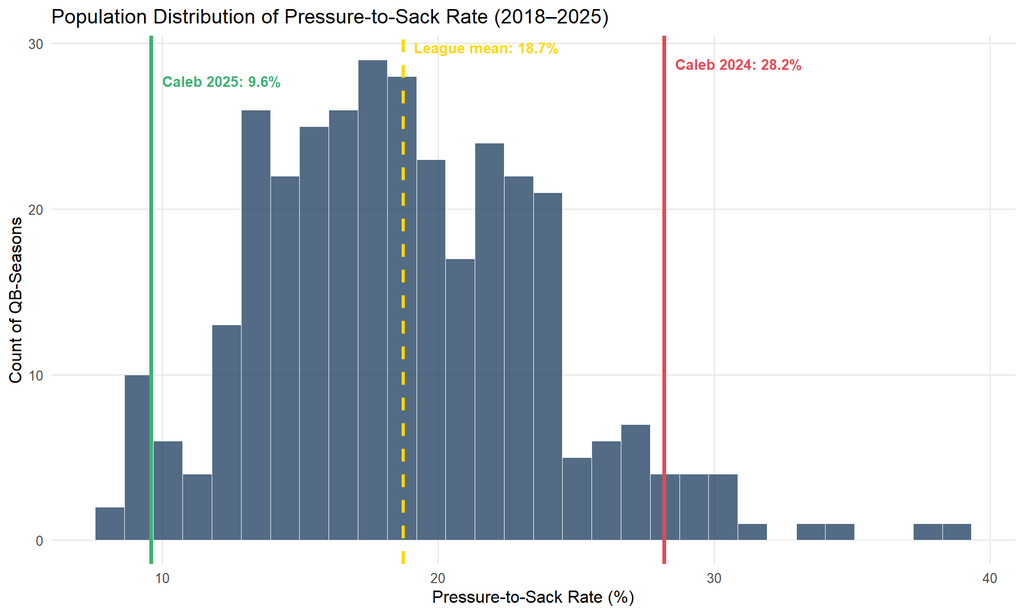

League-wide P2S rate distribution (2018–2025). Caleb’s Year 1 (red) was well above average; Year 2 (green) is elite.

```r
pop_mean <- mean(panel$pressure_to_sack_rate)
pop_sd   <- sd(panel$pressure_to_sack_rate)

caleb_vals <- panel |>
  filter(player_id == CALEB_ID) |>
  select(season, pressure_to_sack_rate) |>
  arrange(season)

ggplot(panel, aes(x = pressure_to_sack_rate)) +
  geom_histogram(bins = 30, fill = "#1a3a5c", alpha = 0.75,
                 color = "white", linewidth = 0.3) +
  geom_vline(xintercept = pop_mean, color = "gold",
             linewidth = 1.2, linetype = "dashed") +
  annotate("text", x = pop_mean + 0.4, y = Inf,
           label = sprintf("League mean: %.1f%%", pop_mean),
           hjust = 0, vjust = 1.5, color = "gold",
           size = 3.5, fontface = "bold") +
  geom_vline(xintercept = caleb_vals$pressure_to_sack_rate[1],
             color = "#e84855", linewidth = 1.4) +
  annotate("text",
           x    = caleb_vals$pressure_to_sack_rate[1] + 0.4, y = Inf,
           label = sprintf("Caleb 2024: %.1f%%",
                           caleb_vals$pressure_to_sack_rate[1]),
           hjust = 0, vjust = 3.0, color = "#e84855",
           size = 3.5, fontface = "bold") +
  geom_vline(xintercept = caleb_vals$pressure_to_sack_rate[2],
             color = "#3bb273", linewidth = 1.4) +
  annotate("text",
           x    = caleb_vals$pressure_to_sack_rate[2] + 0.4, y = Inf,
           label = sprintf("Caleb 2025: %.1f%%",
                           caleb_vals$pressure_to_sack_rate[2]),
           hjust = 0, vjust = 4.5, color = "#3bb273",
           size = 3.5, fontface = "bold") +
  labs(
    x     = "Pressure-to-Sack Rate (%)",
    y     = "Count of QB-Seasons",
    title = "Population Distribution of Pressure-to-Sack Rate (2018–2025)"
  ) +
  theme_minimal(base_size = 12) +
  theme(panel.grid.minor = element_blank())
```

## 5.2 QB Career Trajectories

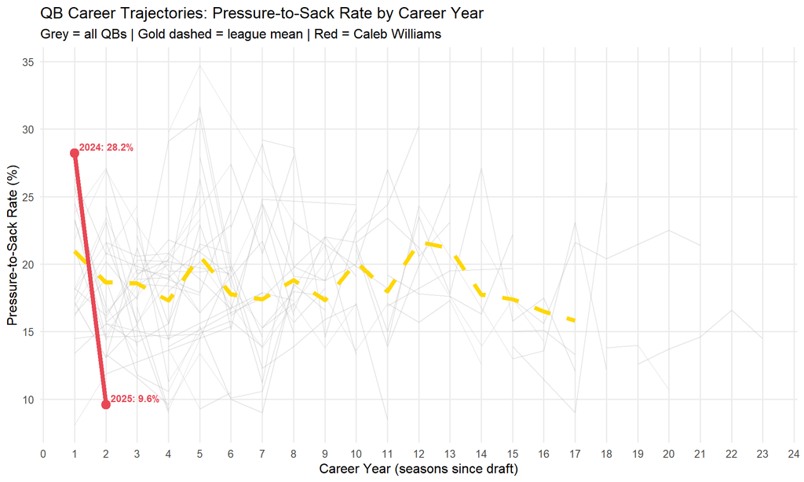

P2S rate by career year. Caleb’s two-season swing is among the most extreme in the dataset.

```r
multi_qbs  <- panel |> count(player_id) |> filter(n >= 3) |> pull(player_id)
pop_traj   <- panel |>
  group_by(career_year) |>
  summarise(mean_p2s = mean(pressure_to_sack_rate), n = n(), .groups = "drop") |>
  filter(n >= 5)
caleb_traj <- filter(panel, player_id == CALEB_ID)

ggplot() +
  geom_line(
    data = filter(panel, player_id %in% multi_qbs),
    aes(x = career_year, y = pressure_to_sack_rate, group = player_id),
    color = "#aaaaaa", linewidth = 0.4, alpha = 0.3
  ) +
  geom_line(data = pop_traj, aes(x = career_year, y = mean_p2s),
            color = "gold", linewidth = 1.8, linetype = "dashed") +
  geom_line(data = caleb_traj,
            aes(x = career_year, y = pressure_to_sack_rate),
            color = "#e84855", linewidth = 2.0) +
  geom_point(data = caleb_traj,
             aes(x = career_year, y = pressure_to_sack_rate),
             color = "#e84855", size = 3.5) +
  geom_text(data = caleb_traj,
            aes(x = career_year, y = pressure_to_sack_rate,
                label = sprintf("%d: %.1f%%", season, pressure_to_sack_rate)),
            nudge_x = 0.15, nudge_y = 0.5, hjust = 0,
            color = "#e84855", size = 3.2, fontface = "bold") +
  scale_x_continuous(breaks = breaks_width(1)) +
  labs(
    x        = "Career Year (seasons since draft)",
    y        = "Pressure-to-Sack Rate (%)",
    title    = "QB Career Trajectories: Pressure-to-Sack Rate by Career Year",
    subtitle = "Grey = all QBs | Gold dashed = league mean | Red = Caleb Williams"
  ) +
  theme_minimal(base_size = 12) +
  theme(panel.grid.minor = element_blank())
```

## 5.3 Year-over-Year P2S Changes

The distribution of season-over-season P2S changes motivates the AR(1) model structure. A wide, near-zero-mean distribution suggests the metric is noisy year-to-year — strong shrinkage back toward the mean is expected.

```r
yoy_changes <- panel |>
  arrange(player_id, season) |>
  group_by(player_id) |>
  mutate(
    p2s_lag    = lag(pressure_to_sack_rate),
    p2s_change = pressure_to_sack_rate - p2s_lag
  ) |>
  ungroup() |>
  filter(!is.na(p2s_lag))

caleb_yoy <- filter(yoy_changes, player_id == CALEB_ID)
yoy_sd    <- sd(yoy_changes$p2s_change)
caleb_z   <- caleb_yoy$p2s_change / yoy_sd
lag1_cor  <- cor(yoy_changes$p2s_lag, yoy_changes$pressure_to_sack_rate)

cat(sprintf(
  "YoY transitions: %d across %d QBs\n  Mean change : %.2f pp\n  SD change   : %.2f pp\n  Caleb Y1→Y2: %.1f pp  (%.1f SDs from zero)\n  Lag-1 r     : %.3f\n",
  nrow(yoy_changes), n_distinct(yoy_changes$player_id),
  mean(yoy_changes$p2s_change), yoy_sd,
  caleb_yoy$p2s_change, caleb_z, lag1_cor
))
```

```
YoY transitions: 232 across 70 QBs
  Mean change : -0.29 pp
  SD change   : 5.67 pp
  Caleb Y1→Y2: -18.6 pp  (-3.3 SDs from zero)
  Lag-1 r     : 0.309
```

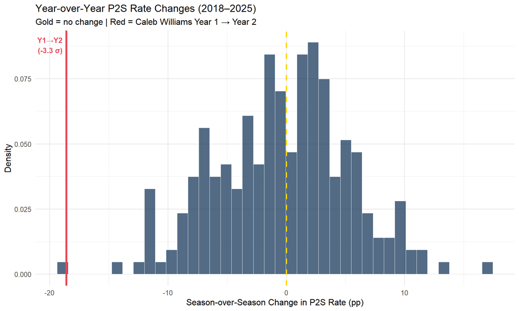

Year-over-year P2S changes across the QB population. Caleb’s -18.6 pp improvement is 3.3 standard deviations from the mean — one of the most extreme swings in the 8-year dataset.

```r
ggplot(yoy_changes, aes(x = p2s_change)) +
  geom_histogram(aes(y = after_stat(density)), bins = 40,
                 fill = "#1a3a5c", alpha = 0.75,
                 color = "white", linewidth = 0.3) +
  geom_vline(xintercept = 0, color = "gold",
             linewidth = 1.0, linetype = "dashed") +
  geom_vline(xintercept = caleb_yoy$p2s_change,
             color = "#e84855", linewidth = 1.4) +
  annotate("text",
           x     = caleb_yoy$p2s_change - 0.3, y = Inf,
           label = sprintf("Caleb Y1→Y2\n%.1f pp (%.1f σ)",
                           caleb_yoy$p2s_change, caleb_z),
           hjust = 1, vjust = 1.4, color = "#e84855",
           size = 3.5, fontface = "bold") +
  labs(
    x        = "Season-over-Season Change in P2S Rate (pp)",
    y        = "Density",
    title    = "Year-over-Year P2S Rate Changes (2018–2025)",
    subtitle = "Gold = no change | Red = Caleb Williams Year 1 → Year 2"
  ) +
  theme_minimal(base_size = 12)
```

## 5.4 Lag-1 Persistence Scatter

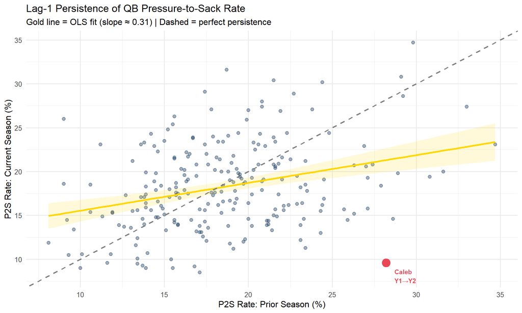

Prior-season P2S rate vs. current-season P2S rate. The OLS slope (~0.31) is the raw persistence signal before the model controls for between-player differences.

```r
ggplot(yoy_changes, aes(x = p2s_lag, y = pressure_to_sack_rate)) +
  geom_point(color = "#1a3a5c", alpha = 0.4, size = 2) +
  geom_smooth(method = "lm", se = TRUE, color = "gold",
              linewidth = 1.2, fill = "gold", alpha = 0.15) +
  geom_abline(slope = 1, intercept = 0, linetype = "dashed",
              color = "grey50", linewidth = 0.8) +
  geom_point(data = caleb_yoy,
             aes(x = p2s_lag, y = pressure_to_sack_rate),
             color = "#e84855", size = 5) +
  geom_text(data = caleb_yoy,
            aes(x = p2s_lag, y = pressure_to_sack_rate,
                label = "Caleb\nY1→Y2"),
            nudge_x = 0.5, nudge_y = -1.5, hjust = 0,
            color = "#e84855", size = 3, fontface = "bold") +
  labs(
    x        = "P2S Rate: Prior Season (%)",
    y        = "P2S Rate: Current Season (%)",
    title    = "Lag-1 Persistence of QB Pressure-to-Sack Rate",
    subtitle = sprintf(
      "Gold line = OLS fit (slope ≈ %.2f) | Dashed = perfect persistence",
      lag1_cor
    )
  ) +
  theme_minimal(base_size = 12)
```

# 6. Model Dataset

Each QB-season requires a valid prior-season P2S observation to serve as the AR(1) lag. This means every QB’s first qualifying season is dropped from the modeling sample — it provides the lag for their second season. QBs with only one qualifying season are excluded.

```r
# Compute lags and within-player TTT change
panel_lagged <- panel |>
  arrange(player_id, season) |>
  group_by(player_id) |>
  mutate(
    p2s_lag   = lag(pressure_to_sack_rate),
    delta_ttt = avg_time_to_throw - lag(avg_time_to_throw)
  ) |>
  ungroup()

# Drop first seasons (no lag available) and rows with missing covariates
model_df <- panel_lagged |>
  drop_na(p2s_lag, draft_season, career_year, starter_year,
          avg_time_to_throw, scramble_rate, delta_ttt) |>
  mutate(trials_col = def_gen_pressures)

# Standardize all continuous covariates and store scaling params
covariates <- c("p2s_lag", "avg_time_to_throw", "scramble_rate",
                "career_year", "starter_year", "delta_ttt")

scale_params <- map(covariates, ~ {
  list(mu = mean(model_df[[.x]]), sig = sd(model_df[[.x]]))
}) |> set_names(covariates)

for (col in covariates) {
  model_df[[paste0(col, "_std")]] <-
    (model_df[[col]] - scale_params[[col]]$mu) / scale_params[[col]]$sig
}

cat(sprintf(
  "Model dataset: %d QB-seasons, %d unique QBs\nCaleb Williams present: %s\n",
  nrow(model_df), n_distinct(model_df$player),
  if (any(model_df$player_id == CALEB_ID)) "YES" else "NO — CHECK PLAYER ID"
))
```

```
Model dataset: 231 QB-seasons, 69 unique QBs
Caleb Williams present: YES
```

```r
# Caleb's entry in the model dataset
model_df |>
  filter(player_id == CALEB_ID) |>
  select(player, season, career_year, p2s_lag, pressure_to_sack_rate,
         avg_time_to_throw, delta_ttt, scramble_rate) |>
  print()
```

```
# A tibble: 1 × 8
  player      season career_year p2s_lag pressure_to_sack_rate avg_time_to_throw
  <chr>        <int>       <int>   <dbl>                 <dbl>             <dbl>
1 Caleb Will…   2025           2    28.2                   9.6              3.23
# ℹ 2 more variables: delta_ttt <dbl>, scramble_rate <dbl>
```

```r
# Expose scaling constants for projection
sp       <- scale_params
LAG_MU   <- sp$p2s_lag$mu;          LAG_SIG  <- sp$p2s_lag$sig
TTT_MU   <- sp$avg_time_to_throw$mu; TTT_SIG  <- sp$avg_time_to_throw$sig
SCR_MU   <- sp$scramble_rate$mu;     SCR_SIG  <- sp$scramble_rate$sig
CYR_MU   <- sp$career_year$mu;       CYR_SIG  <- sp$career_year$sig
SYR_MU   <- sp$starter_year$mu;      SYR_SIG  <- sp$starter_year$sig
DTTT_MU  <- sp$delta_ttt$mu;         DTTT_SIG <- sp$delta_ttt$sig
```

# 7. Bayesian Hierarchical AR(1) Model

## 7.1 Specification

**Likelihood:**
$$\text{sacks}_{i,t} \sim \text{Binomial}(n_{i,t},\; \text{logit}^{-1}(\eta_{i,t}))$$

**Linear predictor:**
$$\eta_{i,t} = \alpha_{\text{QB}_i} + \beta_\text{lag}\,\tilde{p}_{i,t-1} + \beta_{\Delta\text{ttt}}\,\widetilde{\Delta\text{ttt}}_{i,t} + \beta_\text{ttt}\,\tilde{x}_\text{ttt} + \beta_\text{scr}\,\tilde{x}_\text{scr} + \beta_\text{cyr}\,\tilde{x}_\text{cyr} + \beta_\text{syr}\,\tilde{x}_\text{syr}$$

**Priors:**

| Parameter | Prior | Rationale |
| --- | --- | --- |
| Intercept ($\mu_\text{pop}$) | $\mathcal{N}(-1.5,\, 0.3)$ | Logit(0.18) ≈ −1.51; anchors to observed mean P2S |
| All $\beta$s | $\mathcal{N}(0,\, 0.5)$ | Permissive; lets data identify effect sizes |
| $\sigma_\text{pop}$ (between-QB SD) | HalfNormal$(0,\, 0.2)$ | ~4–5 pp spread at +1 SD; matches observed variation |

```r
sack_formula <- bf(
  sacks | trials(trials_col) ~
    p2s_lag_std +
    delta_ttt_std +
    avg_time_to_throw_std +
    scramble_rate_std +
    career_year_std +
    starter_year_std +
    (1 | player)
)

sack_priors <- c(
  prior(normal(-1.5, 0.3), class = "Intercept"),
  prior(normal(0, 0.5),    class = "b"),
  prior(normal(0, 0.2),    class = "sd")
)
```

## 7.2 Prior Predictive Check

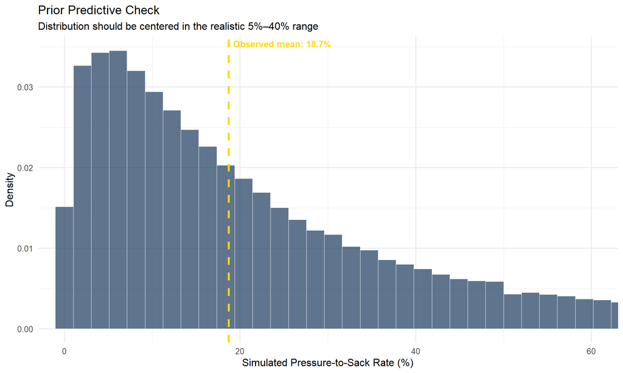

```r
prior_fit <- suppressWarnings(brm(
  formula      = sack_formula,
  data         = model_df,
  family       = binomial(link = "logit"),
  prior        = sack_priors,
  sample_prior = "only",
  iter         = 1000,
  warmup       = 500,
  chains       = 2,
  cores        = 2,
  seed         = RANDOM_SEED,
  silent       = 2
))

tibble(
  p2s = as.vector(posterior_predict(prior_fit) / model_df$trials_col) * 100
) |>
  filter(p2s >= 0, p2s <= 100) |>
  ggplot(aes(x = p2s)) +
  geom_histogram(aes(y = after_stat(density)), bins = 50,
                 fill = "#1a3a5c", alpha = 0.7,
                 color = "white", linewidth = 0.2) +
  geom_vline(xintercept = pop_mean, color = "gold",
             linewidth = 1.2, linetype = "dashed") +
  annotate("text", x = pop_mean + 0.5, y = Inf,
           label = sprintf("Observed mean: %.1f%%", pop_mean),
           hjust = 0, vjust = 1.5, color = "gold",
           size = 3.5, fontface = "bold") +
  coord_cartesian(xlim = c(0, 60)) +
  labs(
    x        = "Simulated Pressure-to-Sack Rate (%)",
    y        = "Density",
    title    = "Prior Predictive Check",
    subtitle = "Distribution should be centered in the realistic 5%–40% range"
  ) +
  theme_minimal(base_size = 12)
```

## 7.3 MCMC Sampling

```r
fit <- suppressWarnings(brm(
  formula   = sack_formula,
  data      = model_df,
  family    = binomial(link = "logit"),
  prior     = sack_priors,
  iter      = N_ITER,
  warmup    = N_WARMUP,
  chains    = N_CHAINS,
  cores     = N_CHAINS,
  control   = list(adapt_delta = ADAPT_DELTA),
  seed      = RANDOM_SEED,
  silent    = 2,
  save_pars = save_pars(all = TRUE)
))
```

```r
cat("Sampling complete.\n\n")
```

```
Sampling complete.
```

```r
summary(fit, robust = TRUE)
```

```
 Family: binomial
  Links: mu = logit
Formula: sacks | trials(trials_col) ~ p2s_lag_std + delta_ttt_std + avg_time_to_throw_std + scramble_rate_std + career_year_std + starter_year_std + (1 | player)
   Data: model_df (Number of observations: 231)
  Draws: 4 chains, each with iter = 3000; warmup = 1000; thin = 1;
         total post-warmup draws = 8000

Multilevel Hyperparameters:
~player (Number of levels: 69)
              Estimate Est.Error l-95% CI u-95% CI Rhat Bulk_ESS Tail_ESS
sd(Intercept)     0.23      0.03     0.18     0.30 1.00     2254     3660

Regression Coefficients:
                      Estimate Est.Error l-95% CI u-95% CI Rhat Bulk_ESS
Intercept                -1.53      0.03    -1.60    -1.46 1.00     2686
p2s_lag_std              -0.02      0.02    -0.06     0.02 1.00     6286
delta_ttt_std             0.02      0.02    -0.02     0.06 1.00     5715
avg_time_to_throw_std    -0.05      0.04    -0.12     0.02 1.00     4442
scramble_rate_std         0.09      0.03     0.03     0.15 1.00     6698
career_year_std           0.00      0.03    -0.07     0.07 1.00     3305
starter_year_std          0.03      0.02    -0.01     0.08 1.00     4374
                      Tail_ESS
Intercept                 3813
p2s_lag_std               5576
delta_ttt_std             6085
avg_time_to_throw_std     5438
scramble_rate_std         6025
career_year_std           4782
starter_year_std          5338

Draws were sampled using sampling(NUTS). For each parameter, Bulk_ESS
and Tail_ESS are effective sample size measures, and Rhat is the potential
scale reduction factor on split chains (at convergence, Rhat = 1).
```

# 8. Convergence Diagnostics

All parameters must satisfy R-hat < 1.01 and ESS ratio > 0.10 for convergence to be declared. Zero divergent transitions confirms the sampler explored the posterior geometry without pathological behavior.

```r
rhat_vals <- rhat(fit)
ess_vals  <- neff_ratio(fit)

pop_params <- c(
  "b_Intercept", "b_p2s_lag_std", "b_delta_ttt_std",
  "b_avg_time_to_throw_std", "b_scramble_rate_std",
  "b_career_year_std", "b_starter_year_std", "sd_player__Intercept"
)

cat("R-hat (target < 1.01):\n")
```

```
R-hat (target < 1.01):
```

```r
walk(pop_params, ~ cat(sprintf(
  "  %-35s %.4f  [%s]\n", .x, rhat_vals[.x],
  if (!is.na(rhat_vals[.x]) && rhat_vals[.x] < 1.01) "OK" else "ISSUE"
)))
```

```
  b_Intercept                         1.0008  [OK]
  b_p2s_lag_std                       1.0005  [OK]
  b_delta_ttt_std                     1.0003  [OK]
  b_avg_time_to_throw_std             1.0001  [OK]
  b_scramble_rate_std                 1.0005  [OK]
  b_career_year_std                   1.0006  [OK]
  b_starter_year_std                  1.0001  [OK]
  sd_player__Intercept                1.0007  [OK]
```

```r
rhat_re_max <- max(rhat_vals[grepl("r_player", names(rhat_vals))], na.rm = TRUE)
cat(sprintf("\n  r_player (max)                      %.4f  [%s]\n",
            rhat_re_max,
            if (rhat_re_max < 1.01) "OK" else "ISSUE"))
```

```
  r_player (max)                      1.0016  [OK]
```

```r
cat("\nESS Ratio (target > 0.10):\n")
```

```
ESS Ratio (target > 0.10):
```

```r
walk(pop_params, ~ cat(sprintf(
  "  %-35s %.3f  [%s]\n", .x, ess_vals[.x],
  if (!is.na(ess_vals[.x]) && ess_vals[.x] > 0.1) "OK" else "LOW"
)))
```

```
  b_Intercept                         0.336  [OK]
  b_p2s_lag_std                       0.697  [OK]
  b_delta_ttt_std                     0.714  [OK]
  b_avg_time_to_throw_std             0.555  [OK]
  b_scramble_rate_std                 0.753  [OK]
  b_career_year_std                   0.413  [OK]
  b_starter_year_std                  0.547  [OK]
  sd_player__Intercept                0.282  [OK]
```

```r
n_div <- sum(nuts_params(fit, pars = "divergent__")$Value)
cat(sprintf("\nDivergent transitions: %d%s\n", n_div,
            if (n_div == 0) " — clean sample" else " — consider raising adapt_delta"))
```

```
Divergent transitions: 0 — clean sample
```

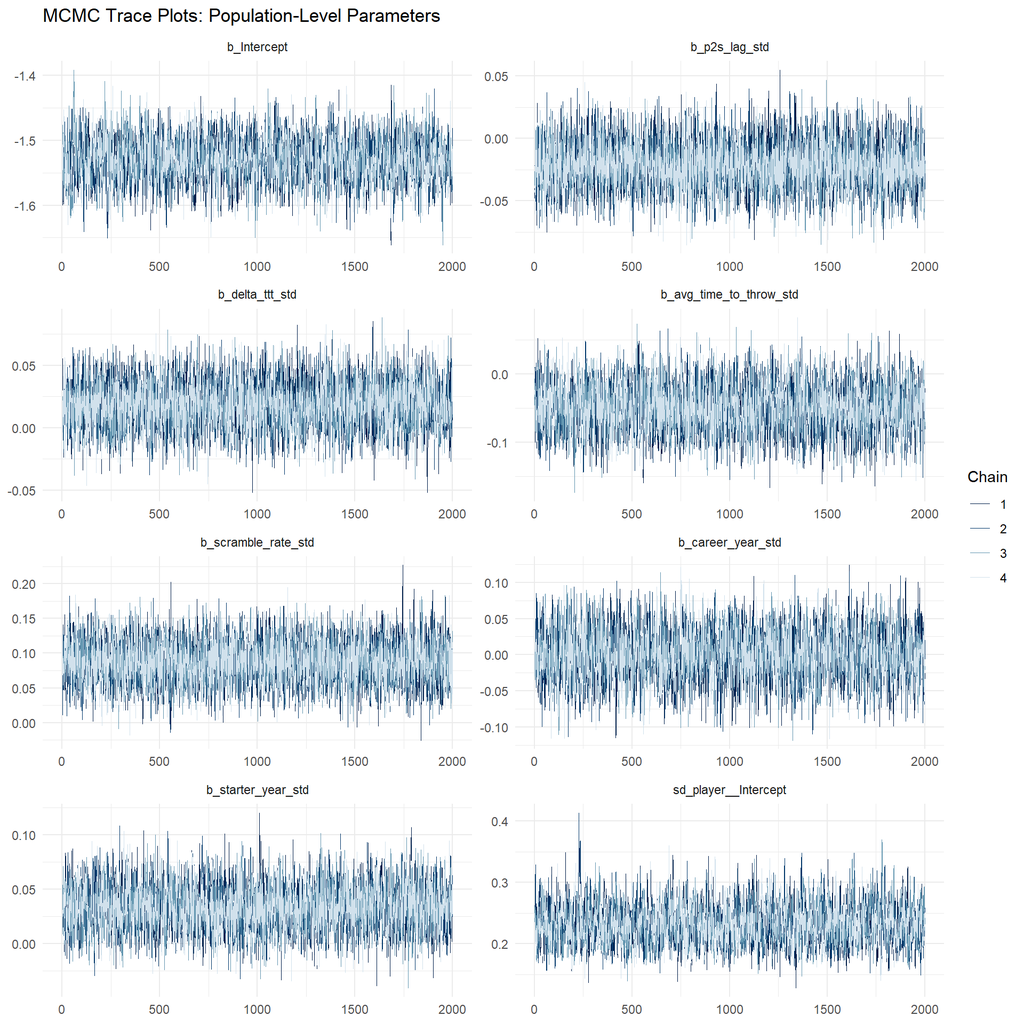

Trace plots for population-level parameters. Well-mixed chains (caterpillar appearance) confirm convergence.

```r
bayesplot_theme_set(theme_minimal(base_size = 11))

mcmc_trace(
  as.array(fit, pars = pop_params),
  facet_args = list(ncol = 2, labeller = label_parsed)
) +
  labs(title = "MCMC Trace Plots: Population-Level Parameters")
```

```r
# Fit a simpler baseline model with no AR(1) lag and no delta_ttt.
# If the full model's ELPD is meaningfully better, the added structure earns
# its complexity. If not, the simpler model is preferred by the data.
fit_simple <- suppressWarnings(brm(
  formula = bf(
    sacks | trials(trials_col) ~
      avg_time_to_throw_std +
      scramble_rate_std +
      career_year_std +
      starter_year_std +
      (1 | player)
  ),
  data      = model_df,
  family    = binomial(link = "logit"),
  prior     = c(
    prior(normal(-1.5, 0.3), class = "Intercept"),
    prior(normal(0, 0.5),    class = "b"),
    prior(normal(0, 0.2),    class = "sd")
  ),
  iter      = N_ITER,
  warmup    = N_WARMUP,
  chains    = N_CHAINS,
  cores     = N_CHAINS,
  control   = list(adapt_delta = ADAPT_DELTA),
  seed      = RANDOM_SEED,
  silent    = 2,
  save_pars = save_pars(all = TRUE)
))
```

[output not shown]

```r
loo_full   <- loo(fit,        moment_match = TRUE)
loo_simple <- loo(fit_simple, moment_match = TRUE)
loo_comp   <- loo_compare(loo_simple, loo_full)

cat("LOO-CV Model Comparison\n")
```

```
LOO-CV Model Comparison
```

```r
cat(strrep("─", 60), "\n")
print(loo_comp)
```

```
           elpd_diff se_diff
fit         0.0       0.0
fit_simple -0.7       2.3
```

```r
cat("\n")
```

```r
elpd_diff  <- loo_comp[2, "elpd_diff"]
elpd_se    <- loo_comp[2, "se_diff"]
ratio      <- abs(elpd_diff) / elpd_se

cat(sprintf("  ELPD difference (full − simple) : %.2f\n", -elpd_diff))
```

```
  ELPD difference (full − simple) : 0.71
```

```r
cat(sprintf("  SE of difference                : %.2f\n",  elpd_se))
```

```
  SE of difference                : 2.28
```

```r
cat(sprintf("  |diff| / SE                     : %.2f\n",  ratio))
```

```
  |diff| / SE                     : 0.31
```

```r
cat("\n  Interpretation:\n")
```

```
  Interpretation:
```

```r
cat("  |diff|/SE > 2 → AR(1) structure meaningfully improves predictive fit.\n")
```

```
  |diff|/SE > 2 → AR(1) structure meaningfully improves predictive fit.
```

```r
cat("  |diff|/SE < 2 → models are roughly equivalent; simpler model preferred.\n")
```

```
  |diff|/SE < 2 → models are roughly equivalent; simpler model preferred.
```

```r
cat("  Either result is informative: equivalence reinforces the finding that\n")
```

```
  Either result is informative: equivalence reinforces the finding that
```

```r
cat("  stable between-player skill (the random intercept) dominates P2S\n")
```

```
  stable between-player skill (the random intercept) dominates P2S
```

```r
cat("  prediction, and the lag adds marginal value.\n")
```

```
  prediction, and the lag adds marginal value.
```

```r
# Hold out 2025. Train on 2018–2024. Predict 2025 for QBs present in both.
# This tests whether the model generalizes to an unseen season -- the same
# generalization being claimed when projecting Caleb's 2026.

train_df <- filter(model_df, season != 2025)
test_df  <- filter(model_df, season == 2025)

fit_holdout <- suppressWarnings(brm(
  formula   = sack_formula,
  data      = train_df,
  family    = binomial(link = "logit"),
  prior     = sack_priors,
  iter      = N_ITER,
  warmup    = N_WARMUP,
  chains    = N_CHAINS,
  cores     = N_CHAINS,
  control   = list(adapt_delta = ADAPT_DELTA),
  seed      = RANDOM_SEED,
  silent    = 2,
  save_pars = save_pars(all = TRUE)
))
```

[output not shown]

```r
# Posterior predictive draws for held-out 2025 observations
ppd_holdout <- posterior_predict(
  fit_holdout,
  newdata           = test_df,
  allow_new_levels  = TRUE,
  sample_new_levels = "gaussian"
)

# Convert sack counts to P2S rate for each draw
ppd_p2s <- sweep(ppd_holdout, 2, test_df$trials_col, "/") * 100

# 80% credible interval coverage
lo80 <- apply(ppd_p2s, 2, quantile, 0.10)
hi80 <- apply(ppd_p2s, 2, quantile, 0.90)
med  <- apply(ppd_p2s, 2, median)
true <- test_df$pressure_to_sack_rate

coverage_80 <- mean(true >= lo80 & true <= hi80)
cat(sprintf(
  "2025 holdout coverage (80%% CrI): %.1f%%  (target: ~80%%)\nn QBs in holdout: %d\n",
  coverage_80 * 100, nrow(test_df)
))
```

```
2025 holdout coverage (80% CrI): 54.3%  (target: ~80%)
n QBs in holdout: 35
```

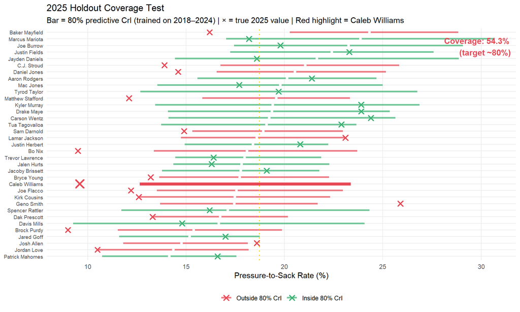

2025 holdout coverage test. Each point is a QB’s true 2025 P2S rate; the bar is the model’s 80% credible interval trained on 2018–2024 only. Well-calibrated = ~80% of true values fall inside the bars.

```r
# Plot: show each QB's true value vs predicted interval
holdout_plot_df <- tibble(
  player = test_df$player,
  true   = true,
  med    = med,
  lo80   = lo80,
  hi80   = hi80,
  inside = true >= lo80 & true <= hi80
) |>
  arrange(med) |>
  mutate(player = factor(player, levels = player))

caleb_holdout <- filter(holdout_plot_df, player == "Caleb Williams")

ggplot(holdout_plot_df, aes(y = player)) +
  geom_linerange(aes(xmin = lo80, xmax = hi80, color = inside),
                 linewidth = 1.2, alpha = 0.7) +
  geom_point(aes(x = med), color = "white", size = 1.5) +
  geom_point(aes(x = true, color = inside), shape = 4, size = 2.5, stroke = 1.2) +
  geom_linerange(data = caleb_holdout,
                 aes(xmin = lo80, xmax = hi80),
                 color = "#e84855", linewidth = 2.0) +
  geom_point(data = caleb_holdout, aes(x = true),
             color = "#e84855", shape = 4, size = 4, stroke = 1.8) +
  scale_color_manual(values = c("TRUE" = "#3bb273", "FALSE" = "#e84855"),
                     labels = c("TRUE" = "Inside 80% CrI", "FALSE" = "Outside 80% CrI"),
                     name   = NULL) +
  geom_vline(xintercept = pop_mean, color = "gold",
             linetype = "dotted", linewidth = 0.8) +
  annotate("text", x = Inf, y = Inf,
           label = sprintf("Coverage: %.1f%%\n(target ~80%%)", coverage_80 * 100),
           hjust = 1.1, vjust = 1.5, size = 4, fontface = "bold",
           color = if (abs(coverage_80 - 0.80) < 0.10) "#3bb273" else "#e84855") +
  labs(
    x        = "Pressure-to-Sack Rate (%)",
    y        = NULL,
    title    = "2025 Holdout Coverage Test",
    subtitle = "Bar = 80% predictive CrI (trained on 2018–2024) | × = true 2025 value | Red highlight = Caleb Williams"
  ) +
  theme_minimal(base_size = 11) +
  theme(
    axis.text.y    = element_text(size = 7),
    legend.position = "bottom",
    panel.grid.minor = element_blank()
  )
```

# 9. Posterior Inference

## 9.1 Fixed-Effect Coefficients

[figure not shown]

```r
beta_params <- c("b_p2s_lag_std", "b_delta_ttt_std", "b_avg_time_to_throw_std",
                 "b_scramble_rate_std", "b_career_year_std", "b_starter_year_std")
beta_labels <- c("P2S Lag (t−1)", "Δ Time to Throw", "Avg Time to Throw",
                 "Scramble Rate", "Career Year", "Starter Year")

mcmc_areas(
  as.array(fit, pars = beta_params),
  prob = 0.80, prob_outer = 0.95, point_est = "median"
) +
  geom_vline(xintercept = 0, color = "red",
             linetype = "dashed", linewidth = 0.8) +
  scale_y_discrete(labels = rev(beta_labels)) +
  labs(
    title    = "Posterior Fixed-Effect Coefficients",
    subtitle = "Positive = higher sack probability given pressure | All covariates standardized",
    x        = "Coefficient (logit scale)"
  )
```

```r
fixef_tbl <- fixef(fit, probs = c(0.025, 0.10, 0.90, 0.975)) |>
  as.data.frame() |>
  rownames_to_column("parameter")

cat("\nFixed-effect posterior summary:\n")
```

```
Fixed-effect posterior summary:
```

```r
print(fixef_tbl)
```

```
              parameter      Estimate  Est.Error         Q2.5          Q10
1             Intercept -1.5307281468 0.03368697 -1.599407491 -1.572697418
2           p2s_lag_std -0.0207498026 0.01938108 -0.059217143 -0.045322557
3         delta_ttt_std  0.0188688991 0.01880471 -0.017870466 -0.005495615
4 avg_time_to_throw_std -0.0493377230 0.03570498 -0.119008386 -0.095516151
5     scramble_rate_std  0.0871445640 0.03088740  0.027743517  0.047000772
6       career_year_std  0.0004797446 0.03489852 -0.069439038 -0.044603119
7      starter_year_std  0.0342544073 0.02075446 -0.005921041  0.007078881
           Q90       Q97.5
1 -1.488397937 -1.46492577
2  0.004442301  0.01801661
3  0.042826729  0.05537023
4 -0.002662218  0.02132802
5  0.127130559  0.14701176
6  0.045272197  0.06701574
7  0.060827160  0.07511829
```

## 9.2 Shrinkage

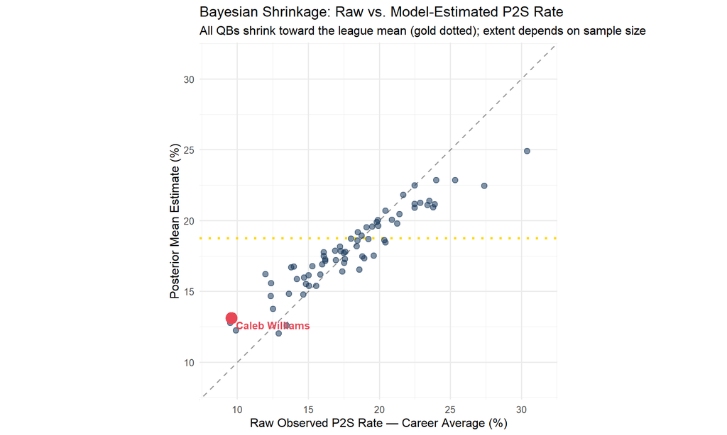

Bayesian shrinkage: raw career-average P2S vs. posterior mean. QBs with fewer seasons are pulled more strongly toward the league mean (gold dotted line).

```r
raw_p2s  <- model_df |>
  group_by(player) |>
  summarise(raw_p2s = mean(pressure_to_sack_rate), .groups = "drop")

qb_coef      <- coef(fit, summary = TRUE)$player
post_p2s_df  <- tibble(
  player       = rownames(qb_coef),
  posterior_p2s = plogis(qb_coef[, "Estimate", "Intercept"]) * 100
)

shrinkage_df <- left_join(raw_p2s, post_p2s_df, by = "player")
caleb_shrink <- filter(shrinkage_df, player == "Caleb Williams")
lim          <- range(c(shrinkage_df$raw_p2s, shrinkage_df$posterior_p2s),
                      na.rm = TRUE) + c(-1, 1)

ggplot(shrinkage_df, aes(x = raw_p2s, y = posterior_p2s)) +
  geom_abline(slope = 1, intercept = 0,
              linetype = "dashed", color = "black", alpha = 0.4) +
  geom_hline(yintercept = pop_mean, color = "gold",
             linetype = "dotted", linewidth = 1.2) +
  geom_point(color = "#1a3a5c", alpha = 0.55, size = 2.5) +
  geom_point(data = caleb_shrink, color = "#e84855", size = 5) +
  geom_text(data = caleb_shrink, aes(label = "Caleb Williams"),
            nudge_x = 0.3, nudge_y = -0.5,
            color = "#e84855", fontface = "bold", size = 3.5, hjust = 0) +
  coord_equal(xlim = lim, ylim = lim) +
  labs(
    x        = "Raw Observed P2S Rate — Career Average (%)",
    y        = "Posterior Mean Estimate (%)",
    title    = "Bayesian Shrinkage: Raw vs. Model-Estimated P2S Rate",
    subtitle = "All QBs shrink toward the league mean (gold dotted); extent depends on sample size"
  ) +
  theme_minimal(base_size = 12)
```

## 9.3 Caleb Williams Posterior Skill Distribution

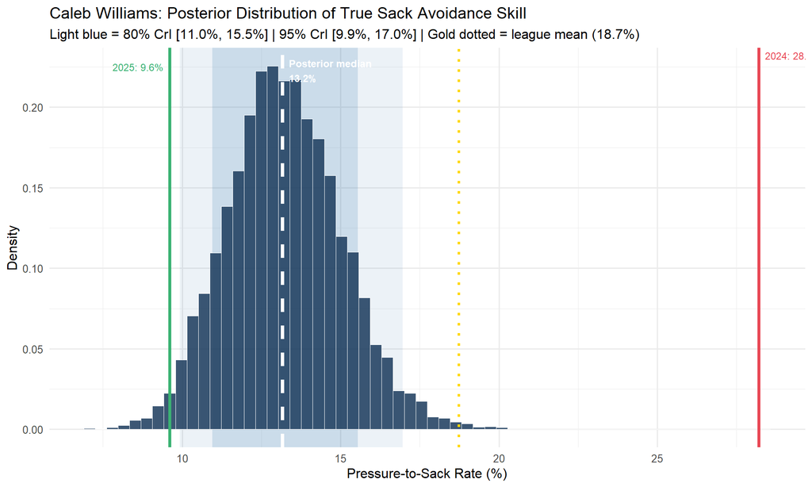

Caleb Williams posterior distribution of true sack avoidance skill. The model’s best estimate of his ‘true talent’ P2S rate, accounting for partial pooling across the QB population.

```r
post_arr      <- as.array(fit)
b_int_vec     <- as.vector(post_arr[,, "b_Intercept"])
caleb_re_vec  <- as.vector(post_arr[,, "r_player[Caleb.Williams,Intercept]"])
caleb_p2s_vec <- plogis(b_int_vec + caleb_re_vec) * 100

hdi_80       <- quantile2(caleb_p2s_vec, probs = c(0.10, 0.90))
hdi_95       <- quantile2(caleb_p2s_vec, probs = c(0.025, 0.975))
caleb_median <- median(caleb_p2s_vec)

caleb_yr1_p2s <- panel |>
  filter(player_id == CALEB_ID) |>
  arrange(season) |>
  slice(1) |>
  pull(pressure_to_sack_rate)

caleb_yr2_p2s <- panel |>
  filter(player_id == CALEB_ID) |>
  arrange(season) |>
  slice(2) |>
  pull(pressure_to_sack_rate)

ggplot(tibble(x = caleb_p2s_vec), aes(x = x)) +
  annotate("rect", xmin = hdi_95[1], xmax = hdi_95[2],
           ymin = -Inf, ymax = Inf, fill = "steelblue", alpha = 0.10) +
  annotate("rect", xmin = hdi_80[1], xmax = hdi_80[2],
           ymin = -Inf, ymax = Inf, fill = "steelblue", alpha = 0.20) +
  geom_histogram(aes(y = after_stat(density)), bins = 60,
                 fill = "#1a3a5c", alpha = 0.85,
                 color = "white", linewidth = 0.2) +
  geom_vline(xintercept = caleb_median, color = "white",
             linewidth = 1.5, linetype = "dashed") +
  geom_vline(xintercept = pop_mean, color = "gold",
             linewidth = 1.2, linetype = "dotted") +
  geom_vline(xintercept = caleb_yr1_p2s, color = "#e84855", linewidth = 1.3) +
  geom_vline(xintercept = caleb_yr2_p2s, color = "#3bb273", linewidth = 1.3) +
  annotate("text", x = caleb_yr1_p2s + 0.2, y = Inf,
           label = sprintf("2024: %.1f%%", caleb_yr1_p2s),
           hjust = 0, vjust = 1.5, color = "#e84855", size = 3.2) +
  annotate("text", x = caleb_yr2_p2s - 0.2, y = Inf,
           label = sprintf("2025: %.1f%%", caleb_yr2_p2s),
           hjust = 1, vjust = 3.0, color = "#3bb273", size = 3.2) +
  annotate("text", x = caleb_median + 0.2, y = Inf,
           label = sprintf("Posterior median\n%.1f%%", caleb_median),
           hjust = 0, vjust = 1.5, color = "white", size = 3.2, fontface = "bold") +
  labs(
    x        = "Pressure-to-Sack Rate (%)",
    y        = "Density",
    title    = "Caleb Williams: Posterior Distribution of True Sack Avoidance Skill",
    subtitle = sprintf(
      "Light blue = 80%% CrI [%.1f%%, %.1f%%] | 95%% CrI [%.1f%%, %.1f%%] | Gold dotted = league mean (%.1f%%)",
      hdi_80[1], hdi_80[2], hdi_95[1], hdi_95[2], pop_mean
    )
  ) +
  theme_minimal(base_size = 12)
```

```r
cat(sprintf(
  "Posterior median : %.2f%%\n80%% CrI          : [%.2f%%, %.2f%%]\n95%% CrI          : [%.2f%%, %.2f%%]\nLeague mean      : %.2f%%\n",
  caleb_median, hdi_80[1], hdi_80[2], hdi_95[1], hdi_95[2], pop_mean
))
```

```
Posterior median : 13.17%
80% CrI          : [10.96%, 15.54%]
95% CrI          : [9.93%, 16.96%]
League mean      : 18.73%
```

# 10. What the Data Is Telling Us

The AR(1) lag coefficient is the model’s answer to the question: *once stable between-player differences are controlled, how much does last season’s P2S rate predict this season’s?*

```r
post_draws_df  <- as_draws_df(fit)
lag_coef_draws <- post_draws_df$b_p2s_lag_std
p_lag_pos      <- mean(lag_coef_draws > 0) * 100
lag_median     <- median(lag_coef_draws)

cat(sprintf(
  "Core finding summary\n%s\n  Lag-1 autocorrelation (raw, unadjusted) : r = %.3f\n  AR(1) lag coefficient (model)           : %.4f\n  P(β_lag > 0)                            : %.1f%%\n  Population YoY change SD               : %.2f pp\n  Caleb Year1→Year2 change               : %.1f pp  (%.1f SDs from zero)\n",
  strrep("─", 60), lag1_cor, lag_median, p_lag_pos,
  yoy_sd, caleb_yoy$p2s_change, caleb_z
))
```

```
Core finding summary
────────────────────────────────────────────────────────────
  Lag-1 autocorrelation (raw, unadjusted) : r = 0.309
  AR(1) lag coefficient (model)           : -0.0209
  P(β_lag > 0)                            : 14.2%
  Population YoY change SD               : 5.67 pp
  Caleb Year1→Year2 change               : -18.6 pp  (-3.3 SDs from zero)
```

```r
cat(sprintf(
  "\nInterpretation\n%s\nThe raw lag-1 correlation of %.3f suggests modest persistence,\n",
  strrep("─", 60), lag1_cor
))
```

```
Interpretation
────────────────────────────────────────────────────────────
The raw lag-1 correlation of 0.309 suggests modest persistence,
```

```r
cat("but once the model controls for stable between-player differences via\n")
```

```
but once the model controls for stable between-player differences via
```

```r
cat("random intercepts, the residual year-to-year signal collapses.\n")
```

```
random intercepts, the residual year-to-year signal collapses.
```

```r
cat(sprintf("P(β_lag > 0) = %.1f%% means the data actively favors β_lag ≤ 0:\n", p_lag_pos))
```

```
P(β_lag > 0) = 14.2% means the data actively favors β_lag ≤ 0:
```

```r
cat("most of the apparent cross-sectional persistence was driven by\n")
```

```
most of the apparent cross-sectional persistence was driven by
```

```r
cat("consistent inter-player differences, not genuine autocorrelation.\n\n")
```

```
consistent inter-player differences, not genuine autocorrelation.
```

```r
cat("What this means for Caleb:\n")
```

```
What this means for Caleb:
```

```r
cat(sprintf(
  "  His Year 1 (28.2%%) and Year 2 (9.6%%) are both used to identify his\n  player random intercept. Because the lag carries negligible weight,\n  his posterior skill estimate (~%.0f%%) sits below his raw two-season\n  average (~%.1f%%).\n\n",
  caleb_median, mean(c(caleb_yr1_p2s, caleb_yr2_p2s))
))
```

[output not shown]

```r
cat(sprintf(
  "  His Year 1→Year 2 swing of %.1f pp is %.1f SDs from the population\n",
  caleb_yoy$p2s_change, abs(caleb_z)
))
```

```
  His Year 1→Year 2 swing of -18.6 pp is 3.3 SDs from the population
```

```r
cat("  mean change — one of the most extreme improvements in the 8-year\n")
```

```
  mean change — one of the most extreme improvements in the 8-year
```

```r
cat("  dataset. The model treats some of that swing as genuine signal\n")
```

```
  dataset. The model treats some of that swing as genuine signal
```

```r
cat("  (absorbed into his player intercept) and some as noise. This is\n")
```

```
  (absorbed into his player intercept) and some as noise. This is
```

```r
cat("  the correct Bayesian response to an extreme single-season result.\n")
```

```
  the correct Bayesian response to an extreme single-season result.
```

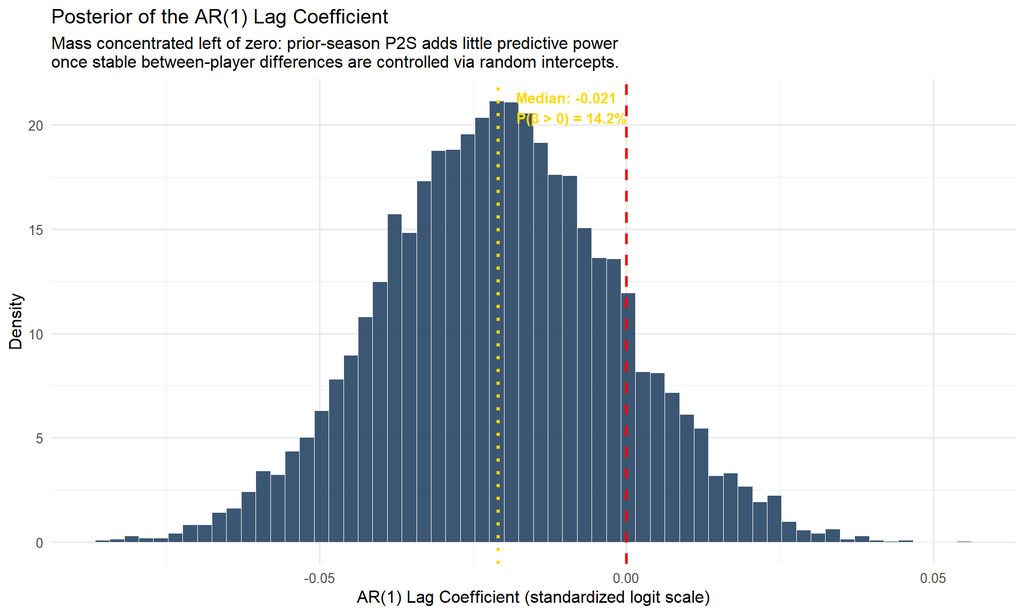

Posterior distribution of the AR(1) lag coefficient. Mass concentrated left of zero confirms that year-to-year P2S changes are largely noise once between-player differences are controlled.

```r
ggplot(tibble(beta = lag_coef_draws), aes(x = beta)) +
  geom_histogram(aes(y = after_stat(density)), bins = 60,
                 fill = "#1a3a5c", alpha = 0.85,
                 color = "white", linewidth = 0.2) +
  geom_vline(xintercept = 0, color = "red",
             linetype = "dashed", linewidth = 1.0) +
  geom_vline(xintercept = lag_median, color = "gold",
             linewidth = 1.2, linetype = "dotted") +
  annotate("text", x = lag_median + 0.003, y = Inf,
           label = sprintf("Median: %.3f\nP(β > 0) = %.1f%%",
                           lag_median, p_lag_pos),
           hjust = 0, vjust = 1.4, color = "gold",
           size = 3.5, fontface = "bold") +
  labs(
    x        = "AR(1) Lag Coefficient (standardized logit scale)",
    y        = "Density",
    title    = "Posterior of the AR(1) Lag Coefficient",
    subtitle = paste0(
      "Mass concentrated left of zero: prior-season P2S adds little predictive power\n",
      "once stable between-player differences are controlled via random intercepts."
    )
  ) +
  theme_minimal(base_size = 12)
```

# 11. Year 3 (2026) Projection

Because the lag coefficient is near zero, the Year 3 projection is driven almost entirely by Caleb’s player random intercept (estimated true talent) and career development terms. Three ΔTTT scenarios are reported but their medians differ by less than 0.5 percentage points — **the neutral scenario (ΔTTT = 0) is the primary result.**

```r
caleb_yr2_row <- model_df |>
  filter(player_id == CALEB_ID) |>
  slice_tail(n = 1)

career_yr3  <- 3L
starter_yr3 <- 3L
lag_yr3     <- caleb_yr2_row$pressure_to_sack_rate
ttt_yr3     <- caleb_yr2_row$avg_time_to_throw
scr_yr3     <- caleb_yr2_row$scramble_rate

# Standardize Year 3 covariates
lag_std <- (lag_yr3     - LAG_MU)  / LAG_SIG
ttt_std <- (ttt_yr3     - TTT_MU)  / TTT_SIG
scr_std <- (scr_yr3     - SCR_MU)  / SCR_SIG
cyr_std <- (career_yr3  - CYR_MU)  / CYR_SIG
syr_std <- (starter_yr3 - SYR_MU)  / SYR_SIG

# Three ΔTTT scenarios (standardized)
dttt_scenarios <- c(
  "Neutral (ΔTTT = 0.00 sec)"      =  (0.00 - DTTT_MU) / DTTT_SIG,
  "Regression (ΔTTT = +0.15 sec)"  =  (0.15 - DTTT_MU) / DTTT_SIG,
  "Improvement (ΔTTT = −0.15 sec)" = (-0.15 - DTTT_MU) / DTTT_SIG
)

# Extract posterior draws
b_int_v    <- post_draws_df$b_Intercept
b_lag_v    <- post_draws_df$b_p2s_lag_std
b_dttt_v   <- post_draws_df$b_delta_ttt_std
b_ttt_v    <- post_draws_df$b_avg_time_to_throw_std
b_scr_v    <- post_draws_df$b_scramble_rate_std
b_cyr_v    <- post_draws_df$b_career_year_std
b_syr_v    <- post_draws_df$b_starter_year_std
caleb_re_v <- post_draws_df[["r_player[Caleb.Williams,Intercept]"]]

project_yr3 <- function(dttt_std) {
  plogis(
    b_int_v + caleb_re_v +
      b_lag_v  * lag_std +
      b_dttt_v * dttt_std +
      b_ttt_v  * ttt_std +
      b_scr_v  * scr_std +
      b_cyr_v  * cyr_std +
      b_syr_v  * syr_std
  ) * 100
}

proj_samples <- map(dttt_scenarios, project_yr3)
neutral_samp <- proj_samples[["Neutral (ΔTTT = 0.00 sec)"]]

cat(sprintf(
  "PRIMARY RESULT — Neutral scenario (ΔTTT = 0)\n%s\n  Median         : %.1f%%\n  80%% CrI        : [%.1f%%, %.1f%%]\n  95%% CrI        : [%.1f%%, %.1f%%]\n",
  strrep("─", 50),
  median(neutral_samp),
  quantile(neutral_samp, 0.10), quantile(neutral_samp, 0.90),
  quantile(neutral_samp, 0.025), quantile(neutral_samp, 0.975)
))
```

```
PRIMARY RESULT — Neutral scenario (ΔTTT = 0)
──────────────────────────────────────────────────
  Median         : 13.0%
  80% CrI        : [10.7%, 15.6%]
  95% CrI        : [9.6%, 17.1%]
```

```r
cat(sprintf("\n  P(Year 3 P2S < Year 2 actual of %.1f%%)  : %.1f%%\n",
            lag_yr3, mean(neutral_samp < lag_yr3) * 100))
```

```
  P(Year 3 P2S < Year 2 actual of 9.6%)  : 2.3%
```

```r
cat(sprintf("  P(Year 3 P2S < league mean of %.1f%%)    : %.1f%%\n",
            pop_mean, mean(neutral_samp < pop_mean) * 100))
```

```
  P(Year 3 P2S < league mean of 18.7%)    : 99.7%
```

```r
cat(sprintf("  P(Year 3 P2S > 25%% [above average])     : %.1f%%\n",
            mean(neutral_samp > 25) * 100))
```

```
  P(Year 3 P2S > 25% [above average])     : 0.0%
```

```r
cat(sprintf("\nAll scenarios (note: spread < 0.5 pp — ΔTTT has minimal leverage)\n%s\n",
            strrep("─", 75)))
```

```
All scenarios (note: spread < 0.5 pp — ΔTTT has minimal leverage)
───────────────────────────────────────────────────────────────────────────
```

```r
cat(sprintf("  %-40s  %5s  %5s  %5s\n", "Scenario", "p10", "p50", "p90"))
```

```
  Scenario                                    p10    p50    p90
```

```r
cat(strrep("─", 75), "\n")
iwalk(proj_samples, ~ cat(sprintf(
  "  %-40s  %4.1f%%  %4.1f%%  %4.1f%%\n",
  .y, quantile(.x, 0.10), median(.x), quantile(.x, 0.90)
)))
```

```
  Neutral (ΔTTT = 0.00 sec)                10.7%  13.0%  15.6%
  Regression (ΔTTT = +0.15 sec)            10.9%  13.2%  15.8%
  Improvement (ΔTTT = −0.15 sec)         10.5%  12.8%  15.4%
```

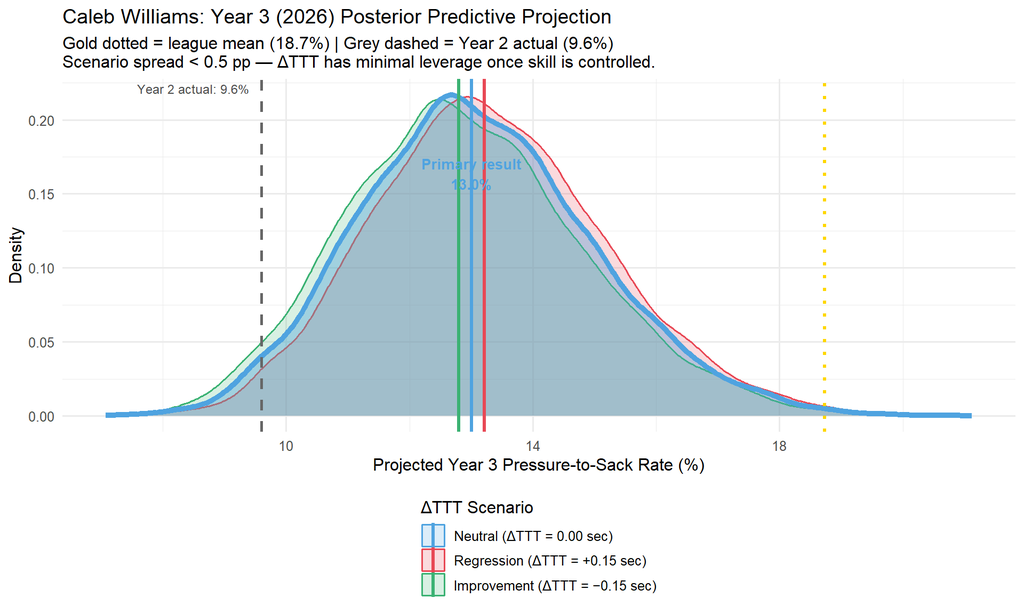

Year 3 (2026) posterior predictive projection. The near-identical distributions across all three scenarios confirm that ΔTTT has negligible leverage once individual skill is controlled — the neutral scenario (blue) is the primary result.

```r
scenario_colors <- c("#4fa3e0", "#e84855", "#3bb273")

proj_df <- imap_dfr(proj_samples, ~ tibble(scenario = .y, x = .x)) |>
  mutate(scenario = factor(scenario, levels = names(dttt_scenarios)))

proj_medians <- proj_df |>
  group_by(scenario) |>
  summarise(med = median(x), .groups = "drop")

neutral_med <- proj_medians$med[proj_medians$scenario == "Neutral (ΔTTT = 0.00 sec)"]

ggplot(proj_df, aes(x = x, fill = scenario, color = scenario)) +
  geom_density(alpha = 0.20, linewidth = 0.6) +
  geom_density(
    data    = filter(proj_df, scenario == "Neutral (ΔTTT = 0.00 sec)"),
    aes(x = x), color = "#4fa3e0", linewidth = 1.8,
    fill = "#4fa3e0", alpha = 0.25, inherit.aes = FALSE
  ) +
  geom_vline(data = proj_medians,
             aes(xintercept = med, color = scenario), linewidth = 1.2) +
  geom_vline(xintercept = pop_mean, color = "gold",
             linetype = "dotted", linewidth = 1.2) +
  geom_vline(xintercept = lag_yr3, color = "grey40",
             linetype = "dashed", linewidth = 0.9) +
  annotate("text", x = lag_yr3 - 0.2, y = Inf,
           label = sprintf("Year 2 actual: %.1f%%", lag_yr3),
           hjust = 1, vjust = 1.5, color = "grey30", size = 3.2) +
  annotate("text", x = neutral_med, y = Inf,
           label = sprintf("Primary result\n%.1f%%", neutral_med),
           hjust = 0.5, vjust = 3.5,
           color = "#4fa3e0", size = 3.5, fontface = "bold") +
  scale_fill_manual(values  = setNames(scenario_colors, levels(proj_df$scenario))) +
  scale_color_manual(values = setNames(scenario_colors, levels(proj_df$scenario))) +
  labs(
    x        = "Projected Year 3 Pressure-to-Sack Rate (%)",
    y        = "Density",
    title    = "Caleb Williams: Year 3 (2026) Posterior Predictive Projection",
    subtitle = sprintf(
      "Gold dotted = league mean (%.1f%%) | Grey dashed = Year 2 actual (%.1f%%)\nScenario spread < 0.5 pp — ΔTTT has minimal leverage once skill is controlled.",
      pop_mean, lag_yr3
    ),
    fill  = "ΔTTT Scenario",
    color = "ΔTTT Scenario"
  ) +
  theme_minimal(base_size = 12) +
  theme(legend.position = "bottom", legend.direction = "vertical")
```

## 11.1 Projected Sack Counts

```r
assumed_pressures <- c(200L, 240L, 280L)

cat(sprintf("Projected sack counts by pressure volume (Median [p10–p90])\n%s\n",
            strrep("─", 80)))
```

```
Projected sack counts by pressure volume (Median [p10–p90])
────────────────────────────────────────────────────────────────────────────────
```

```r
cat(sprintf("  %-42s", "Scenario"))
```

```
  Scenario
```

```r
walk(assumed_pressures, ~ cat(sprintf("  %d pressures", .x)))
```

```
  200 pressures  240 pressures  280 pressures
```

```r
cat(sprintf("\n  %s\n", strrep("─", 75)))
iwalk(proj_samples, function(samp, nm) {
  cat(sprintf("  %-42s", nm))
  walk(assumed_pressures, function(p) {
    draws <- rbinom(length(samp), size = p, prob = samp / 100)
    cat(sprintf("  %2d [%2d–%2d]",
                round(median(draws)),
                round(quantile(draws, 0.10)),
                round(quantile(draws, 0.90))))
  })
  cat("\n")
})
```

```
  Neutral (ΔTTT = 0.00 sec)                  26 [19–34]  31 [23–41]  36 [27–47]
  Regression (ΔTTT = +0.15 sec)              26 [19–35]  32 [23–41]  37 [28–47]
  Improvement (ΔTTT = −0.15 sec)           25 [18–34]  31 [22–40]  36 [26–46]
```

# 12. Limitations

**Scheme confound (most significant).** Ben Johnson’s arrival in Chicago materially changed Caleb’s operating environment: faster tempo, pre-snap motion, and shorter intended release windows all reduce P2S independently of QB skill. `avg_time_to_throw` and `delta_ttt` partially absorb this confound, but both are themselves scheme-driven. Isolating QB skill from coordinator quality would require a coach fixed effect or scheme-quality control variable.

**Two seasons, one lag transition.** Caleb contributes exactly one lag-to-current observation (2024→2025) to the AR(1) model. His random intercept is identified primarily by the population prior and this single transition. Year 3 data will be the first season where his individual intercept is meaningfully constrained by his own history.

**AR(1) structure excludes first seasons.** Each QB’s first qualifying season cannot enter the model as a response — it serves as the lag for their second season. This reduces the modeling sample from ~333 to ~231 QB-seasons and excludes QBs with only one qualifying season. The tradeoff is accepted given the structural value of the lag term.

**Pressure volume is assumed, not modeled.** Projecting sack counts requires an assumption about how many pressures Caleb will face in 2026. This is itself uncertain and is reported across a plausible range (200–280 pressures) rather than as a single forecast.

**OL quality residual.** P2S rate controls for OL quality better than raw sack count, but OL quality also affects *pressure type* — a strong OL may generate cleaner, more escapable pressures than stunt-heavy designs allowed by a weaker line. This residual confound cannot be removed without play-level data.

# 13. Session Info

```r
session_pkgs <- c("brms", "tidybayes", "posterior", "bayesplot",
                  "nflreadr", "tidyverse", "stringdist")

cat(sprintf("R: %s\n", R.version.string))
```

```
R: R version 4.5.2 (2025-10-31 ucrt)
```

```r
walk(session_pkgs, ~ cat(sprintf("  %-12s %s\n", .x, packageVersion(.x))))
```

```
  brms         2.23.0
  tidybayes    3.0.7
  posterior    1.7.0
  bayesplot    1.15.0
  nflreadr     1.5.0
  tidyverse    2.0.0
  stringdist   0.9.17
```

```r
if (requireNamespace("cmdstanr", quietly = TRUE)) {
  tryCatch(
    cat(sprintf("  %-12s %s\n", "CmdStan", cmdstanr::cmdstan_version())),
    error = function(e) cat("  CmdStan      (not installed)\n")
  )
}
```

```
  CmdStan      2.38.0
```